# Establishing atttiudes towards novel stimuli via the IAT

Experiment 3

Ian Hussey[^1]

02 October 2017

# Descriptive statistics

## Full sample

### Age

|  | n | mean | sd |
| --- | --- | --- | --- |
| age | 449 | 34.9 | 11.46 |

### Gender

| gender | n |
| --- | --- |
| ? | 1 |
| 36 | 1 |
| fema | 1 |
| female | 222 |
| male | 222 |
| non-binary | 1 |
| transman | 1 |

## Analytic sample

I.e., after applying inclusion/exclusion criteria.

### Conditions

| IAT_condition | n |
| --- | --- |
| Flowers-Chinese IAT | 213 |
| Insects-Chinese IAT | 214 |

| attribute_condition | n |
| --- | --- |
| nonword attributes | 225 |
| opposite valenced attributes | 202 |

| interaction(IAT_condition, attribute_condition) | n |
| --- | --- |
| Flowers-Chinese IAT.nonword attributes | 104 |
| Insects-Chinese IAT.nonword attributes | 121 |
| Flowers-Chinese IAT.opposite valenced attributes | 109 |
| Insects-Chinese IAT.opposite valenced attributes | 93 |

### Performance on the IAT and SC-IAT

| rowname | n | mean | sd |
| --- | --- | --- | --- |
| IAT_mean_RT | 427 | 797.51 | 161.56 |
| IAT_perc_acc | 427 | 90.62 | 9.48 |
| SCIAT_mean_RT | 427 | 670.33 | 122.78 |
| SCIAT_perc_acc | 427 | 94.29 | 4.97 |

# Outlier removal

RTs <300 ms trimmed. Reciprocal transformation applied. Outliers defined as > 2.5 SD from mean and excluded.

```
## [1] "Function outlier() has screened 59780 trial(s) in total. Of these were 1041 trial(s) identified as outliers (1.74%)."
```

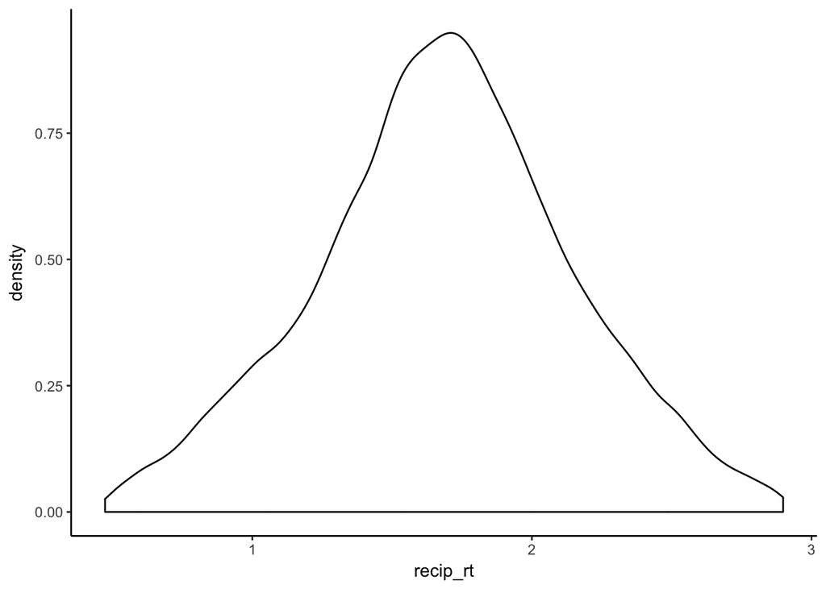

# H1: Differences in SC-IAT effects between IAT contrast category conditions, in the opposite attributes condition

This seeks to replicate the effect found in previous studies. The Chinese characters should acquire the opposite valence to the category they were contrasted with in the IAT (i.e., flowers vs insects).

SCIAT effects are expected to differ between the IAT conditions, where the Chinese characters acquire the opposite valence to the images they were contrasted with in the IAT.

## Linear mixed model

- Hypothesis refers to the IAT_condition*SCIAT_block interaction effect.
- Confidence intervals via Wald estimation.

```r
# opposite condition only
opp_val_data_only <- SCIAT_data %>%
  filter(attribute_condition == "opposite valenced attributes")

model_h1 <- lmer(recip_rt ~ SCIAT_block * IAT_condition + (SCIAT_block | participant),
                contrasts = list(SCIAT_block = "contr.sum", IAT_condition = "contr.sum"),
                data = opp_val_data_only)
```

## Summary

|  |  | B | CI | std. Beta | CI | p |
| --- | --- | --- | --- | --- | --- | --- |
| Fixed Parts |  |  |  |  |  |  |
| (Intercept) |  | 1.702 | 1.674 – 1.729 |  |  | .000000 |
| SCIAT_block1 |  | -0.004 | -0.012 – 0.005 | -0.008 | -0.026 – 0.011 | .409948 |
| IAT_condition1 |  | -0.004 | -0.031 – 0.024 | -0.008 | -0.068 – 0.053 | .803124 |
| SCIAT_block1:IAT_condition1 |  | 0.016 | 0.007 – 0.024 | 0.034 | 0.016 – 0.052 | .000277 |
| Random Parts |  |  |  |  |  |  |
| σ<sup>2</sup> |  | 0.170 |  |  |  |  |
| τ<sub>00, participant</sub> |  | 0.042 |  |  |  |  |
| ρ<sub>01</sub> |  | -0.295 |  |  |  |  |
| N<sub>participant</sub> |  | 202 |  |  |  |  |
| ICC<sub>participant</sub> |  | 0.200 |  |  |  |  |
| Observations |  | 27776 |  |  |  |  |
| R<sup>2</sup> / Ω<sub>0</sub><sup>2</sup> |  | .203 / .203 |  |  |  |  |

## Plot effects

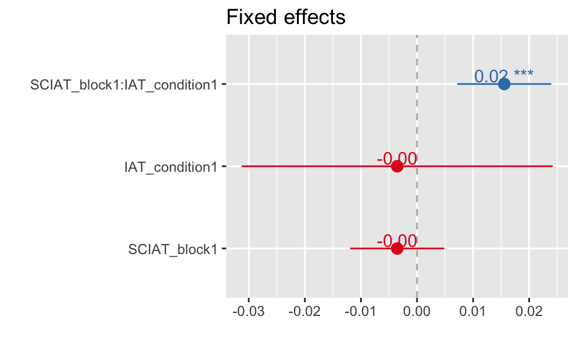

## Table predictions

| SCIAT block | IAT condition | fit | se | lower | upper |
| --- | --- | --- | --- | --- | --- |
| Chinese negative | Flowers-Chinese IAT | 1.71 | 0.02 | 1.67 | 1.75 |
| Chinese positive | Flowers-Chinese IAT | 1.69 | 0.02 | 1.65 | 1.72 |
| Chinese negative | Insects-Chinese IAT | 1.69 | 0.02 | 1.64 | 1.73 |
| Chinese positive | Insects-Chinese IAT | 1.72 | 0.02 | 1.68 | 1.77 |

## Plot predictions

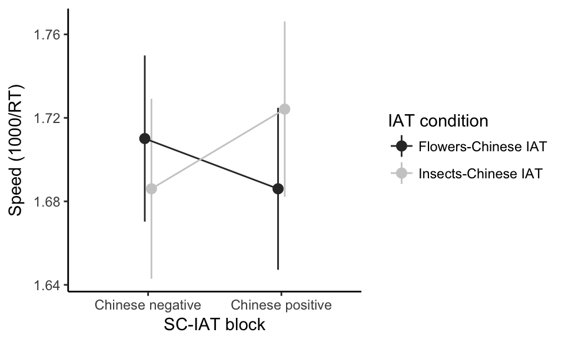

# E1: No evidence of differences in SCIAT effects between IAT contrast category conditions, in the non-opposites attributes condition

We expected that when the positive-negative attribute stimuli and category labels were changed to non-words, the evaluative learning effect would disappear.

## Linear mixed model

- Hypothesis refers to the IAT_condition*SCIAT_block interaction effect, which we expect to be non-significant.
- Confidence intervals via Wald estimation.

```r
# non-opposite condition only
nonword_val_data_only <- SCIAT_data %>%
  filter(attribute_condition == "nonword attributes")

model_e1 <- lmer(recip_rt ~ SCIAT_block * IAT_condition + (SCIAT_block | participant),
                contrasts = list(SCIAT_block = "contr.sum", IAT_condition = "contr.sum"),
                data = nonword_val_data_only)
```

## Summary

|  |  | B | CI | std. Beta | CI | p |
| --- | --- | --- | --- | --- | --- | --- |
| Fixed Parts |  |  |  |  |  |  |
| (Intercept) |  | 1.676 | 1.648 – 1.703 |  |  | .000000 |
| SCIAT_block1 |  | 0.003 | -0.005 – 0.011 | 0.007 | -0.011 – 0.024 | .468155 |
| IAT_condition1 |  | 0.009 | -0.019 – 0.036 | 0.019 | -0.041 – 0.079 | .532654 |
| SCIAT_block1:IAT_condition1 |  | 0.005 | -0.003 – 0.013 | 0.011 | -0.007 – 0.029 | .233079 |
| Random Parts |  |  |  |  |  |  |
| σ<sup>2</sup> |  | 0.164 |  |  |  |  |
| τ<sub>00, participant</sub> |  | 0.047 |  |  |  |  |
| ρ<sub>01</sub> |  | -0.315 |  |  |  |  |
| N<sub>participant</sub> |  | 225 |  |  |  |  |
| ICC<sub>participant</sub> |  | 0.221 |  |  |  |  |
| Observations |  | 30963 |  |  |  |  |
| R<sup>2</sup> / Ω<sub>0</sub><sup>2</sup> |  | .222 / .221 |  |  |  |  |

## Plot effects

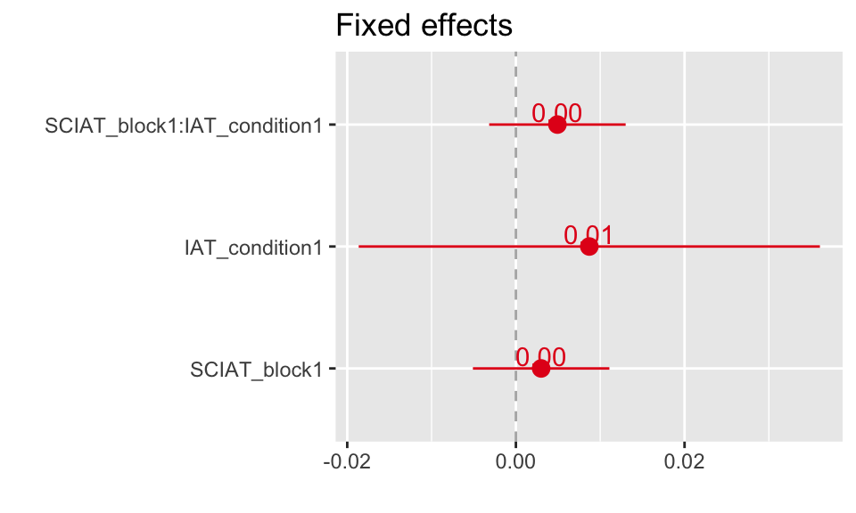

## Table predictions

| SCIAT block | IAT condition | fit | se | lower | upper |
| --- | --- | --- | --- | --- | --- |
| Chinese negative | Flowers-Chinese IAT | 1.69 | 0.02 | 1.65 | 1.73 |
| Chinese positive | Flowers-Chinese IAT | 1.68 | 0.02 | 1.64 | 1.72 |
| Chinese negative | Insects-Chinese IAT | 1.67 | 0.02 | 1.63 | 1.70 |
| Chinese positive | Insects-Chinese IAT | 1.67 | 0.02 | 1.63 | 1.71 |

## Plot predictions

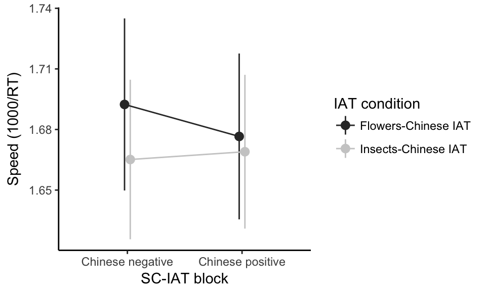

# H2: Evaluative learning effect on the SC-IAT is weakened when the analogy within the IAT is undermined

More specifically, the effect described in H2 should be lower in the non-opposite attributes IAT than the opposite attributes IAT. I.e., the difference between the conditions should itself be significant.

## Model

- Hypothesis refers to the IAT_condition * SCIAT_block * attribute_condition interaction effect.
- Confidence intervals via Wald estimation.

```r
model_h2 <- lmer(recip_rt ~ SCIAT_block * IAT_condition * attribute_condition + (SCIAT_block | participant),
                contrasts = list(SCIAT_block = "contr.sum",
                                 IAT_condition = "contr.sum",
                                 attribute_condition = "contr.sum"),
                data = SCIAT_data)
```

## Summary

|  |  | B | CI | std. Beta | CI | p |
| --- | --- | --- | --- | --- | --- | --- |
| Fixed Parts |  |  |  |  |  |  |
| (Intercept) |  | 1.689 | 1.669 – 1.708 |  |  | .000000 |
| SCIAT_block1 |  | -0.000 | -0.006 – 0.006 | -0.001 | -0.013 – 0.012 | .928866 |
| IAT_condition1 |  | 0.003 | -0.017 – 0.022 | 0.006 | -0.037 – 0.048 | .794827 |
| attribute_condition1 |  | -0.013 | -0.032 – 0.007 | -0.028 | -0.071 – 0.014 | .194756 |
| SCIAT_block1:IAT_condition1 |  | 0.010 | 0.004 – 0.016 | 0.022 | 0.010 – 0.035 | .000581 |
| SCIAT_block1:attribute_condition1 |  | 0.003 | -0.003 – 0.009 | 0.007 | -0.006 – 0.020 | .272912 |
| IAT_condition1:attribute_condition1 |  | 0.006 | -0.013 – 0.026 | 0.013 | -0.029 – 0.056 | .538947 |
| SCIAT_block1:IAT_condition1:attribute_condition1 |  | -0.005 | -0.011 – 0.001 | -0.012 | -0.024 – 0.001 | .073966 |
| Random Parts |  |  |  |  |  |  |
| σ<sup>2</sup> |  | 0.167 |  |  |  |  |
| τ<sub>00, participant</sub> |  | 0.045 |  |  |  |  |
| ρ<sub>01</sub> |  | -0.306 |  |  |  |  |
| N<sub>participant</sub> |  | 427 |  |  |  |  |
| ICC<sub>participant</sub> |  | 0.211 |  |  |  |  |
| Observations |  | 58739 |  |  |  |  |
| R<sup>2</sup> / Ω<sub>0</sub><sup>2</sup> |  | .214 / .213 |  |  |  |  |

## Plot effects

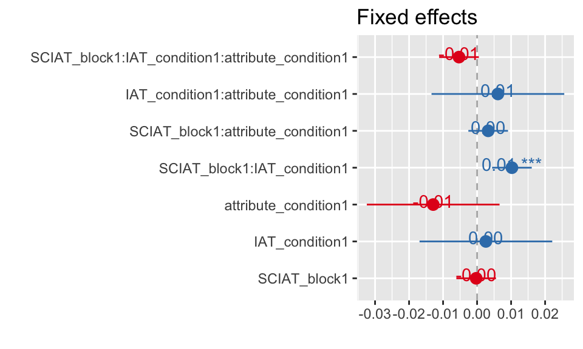

## Table predictions

| SCIAT block | IAT condition | attribute_condition | fit | se | lower | upper |
| --- | --- | --- | --- | --- | --- | --- |
| Chinese negative | Flowers-Chinese IAT | nonword attributes | 1.69 | 0.02 | 1.65 | 1.73 |
| Chinese positive | Flowers-Chinese IAT | nonword attributes | 1.68 | 0.02 | 1.64 | 1.72 |
| Chinese negative | Insects-Chinese IAT | nonword attributes | 1.67 | 0.02 | 1.63 | 1.70 |
| Chinese positive | Insects-Chinese IAT | nonword attributes | 1.67 | 0.02 | 1.63 | 1.71 |
| Chinese negative | Flowers-Chinese IAT | opposite valenced attributes | 1.71 | 0.02 | 1.67 | 1.75 |
| Chinese positive | Flowers-Chinese IAT | opposite valenced attributes | 1.69 | 0.02 | 1.65 | 1.73 |
| Chinese negative | Insects-Chinese IAT | opposite valenced attributes | 1.69 | 0.02 | 1.64 | 1.73 |
| Chinese positive | Insects-Chinese IAT | opposite valenced attributes | 1.72 | 0.02 | 1.68 | 1.77 |

## Plot predictions

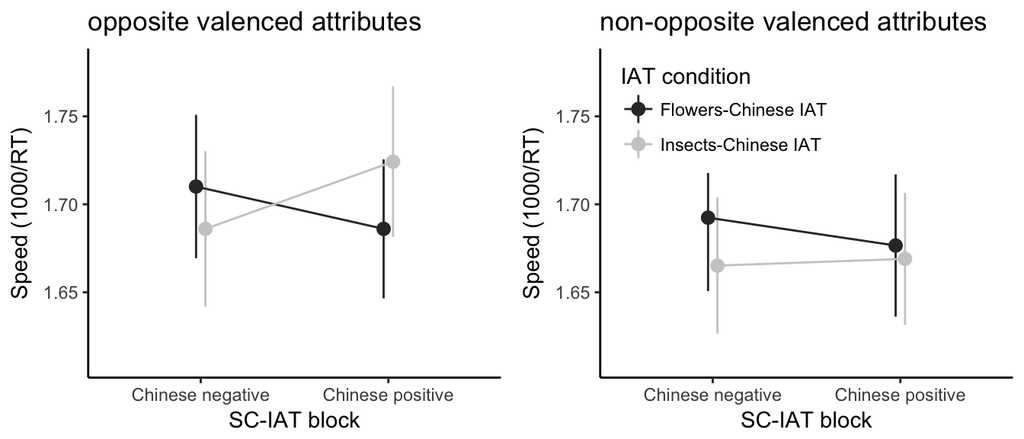

# E2: Evaluative learning effect on the SC-IAT is weakened when the analogy within the IAT is undermined (less conservative model)

Given the marginal effect in the above analysis, we constructed a less conservative exploratory model that removed the random slope for SC-IAT block. This model therefore focused on assessing group differences in the SC-IAT effect and did not attempt to model differences in the SC-IAT effect at the individual level. It provides a less conservative, exploratory test of H2.

## Model

- Hypothesis refers to the IAT_condition * SCIAT_block * attribute_condition interaction effect.
- Confidence intervals via Wald estimation.

```r
model_e2 <- lmer(recip_rt ~ SCIAT_block * IAT_condition * attribute_condition + (1 | participant),
                contrasts = list(SCIAT_block = "contr.sum",
                                 IAT_condition = "contr.sum",
                                 attribute_condition = "contr.sum"),
                data = SCIAT_data)
```

## Summary

|  |  | B | CI | std. Beta | CI | p |
| --- | --- | --- | --- | --- | --- | --- |
| Fixed Parts |  |  |  |  |  |  |
| (Intercept) |  | 1.689 | 1.669 – 1.708 |  |  | .000000 |
| SCIAT_block1 |  | -0.000 | -0.003 – 0.003 | -0.000 | -0.008 – 0.007 | .930996 |
| IAT_condition1 |  | 0.003 | -0.017 – 0.022 | 0.006 | -0.037 – 0.048 | .790423 |
| attribute_condition1 |  | -0.013 | -0.032 – 0.007 | -0.028 | -0.071 – 0.014 | .195613 |
| SCIAT_block1:IAT_condition1 |  | 0.010 | 0.007 – 0.014 | 0.022 | 0.015 – 0.030 | .000000 |
| SCIAT_block1:attribute_condition1 |  | 0.003 | -0.000 – 0.007 | 0.007 | -0.000 – 0.014 | .059623 |
| IAT_condition1:attribute_condition1 |  | 0.006 | -0.013 – 0.026 | 0.013 | -0.029 – 0.056 | .540616 |
| SCIAT_block1:IAT_condition1:attribute_condition1 |  | -0.005 | -0.009 – -0.002 | -0.012 | -0.019 – -0.005 | .001498 |
| Random Parts |  |  |  |  |  |  |
| σ<sup>2</sup> |  | 0.170 |  |  |  |  |
| τ<sub>00, participant</sub> |  | 0.041 |  |  |  |  |
| N<sub>participant</sub> |  | 427 |  |  |  |  |
| ICC<sub>participant</sub> |  | 0.193 |  |  |  |  |
| Observations |  | 58739 |  |  |  |  |
| R<sup>2</sup> / Ω<sub>0</sub><sup>2</sup> |  | .198 / .197 |  |  |  |  |

## Plot effects

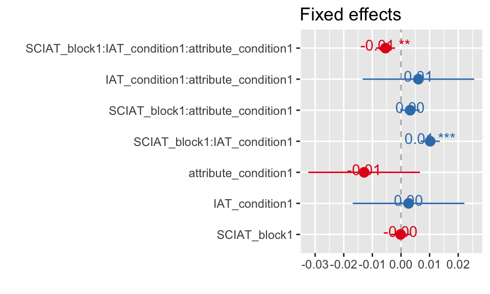

## Table predictions

| SCIAT block | IAT condition | attribute_condition | fit | se | lower | upper |
| --- | --- | --- | --- | --- | --- | --- |
| Chinese negative | Flowers-Chinese IAT | nonword attributes | 1.69 | 0.02 | 1.65 | 1.73 |
| Chinese positive | Flowers-Chinese IAT | nonword attributes | 1.68 | 0.02 | 1.64 | 1.72 |
| Chinese negative | Insects-Chinese IAT | nonword attributes | 1.67 | 0.02 | 1.63 | 1.70 |
| Chinese positive | Insects-Chinese IAT | nonword attributes | 1.67 | 0.02 | 1.63 | 1.71 |
| Chinese negative | Flowers-Chinese IAT | opposite valenced attributes | 1.71 | 0.02 | 1.67 | 1.75 |
| Chinese positive | Flowers-Chinese IAT | opposite valenced attributes | 1.69 | 0.02 | 1.65 | 1.72 |
| Chinese negative | Insects-Chinese IAT | opposite valenced attributes | 1.69 | 0.02 | 1.64 | 1.73 |
| Chinese positive | Insects-Chinese IAT | opposite valenced attributes | 1.72 | 0.02 | 1.68 | 1.77 |

## Plot predictions

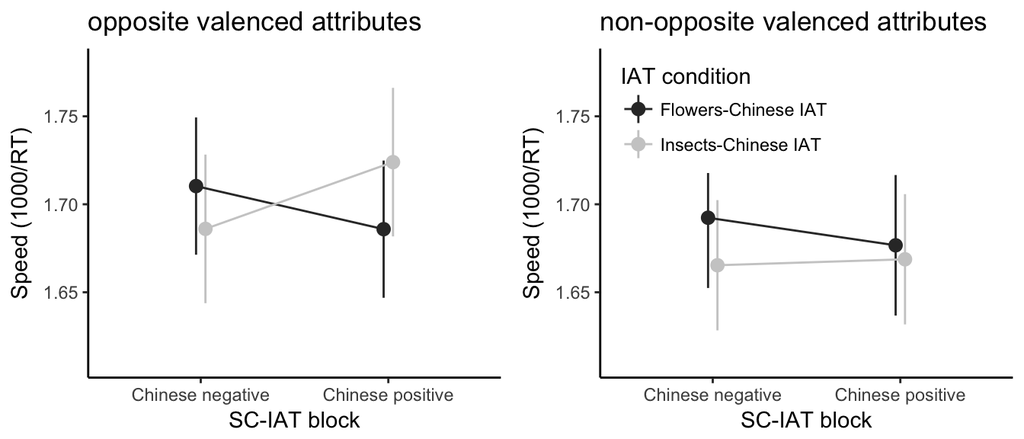

# H3: Differences in ratings effects between IAT contrast category conditions, in the opposite attributes condition

This seeks to replicate the effect found in previous studies. The Chinese characters should acquire the opposite valence to the category they were contrasted with in the IAT (i.e., flowers vs insects).

Ratings effects are expected to differ between the IAT conditions, where the Chinese characters acquire the opposite valence to the images they were contrasted with in the IAT.

## Linear mixed model

```r
# exclude participants who had more than 10% of trials in less than 300ms, and make variables factors
ratings_data <-
  read.csv("data/processed/processed data - ratings item data.csv") %>%
  dplyr::mutate(participant = as.factor(participant),
                attribute_condition = as.factor(attribute_condition),
                IAT_condition = as.factor(IAT_condition)) %>%
  filter(exclude == FALSE)

#sapply(SCIAT_data, class)

# non-opposite condition only
opp_val_data_only_ratings <- ratings_data %>%
  filter(attribute_condition == "opposite valenced attributes")

model_h3 <- lmer(ratings ~ IAT_condition + (1 | participant),
                contrasts = list(IAT_condition = "contr.sum"),
                data = opp_val_data_only_ratings)
```

## Summary

|  |  | B | CI | std. Beta | CI | p |
| --- | --- | --- | --- | --- | --- | --- |
| Fixed Parts |  |  |  |  |  |  |
| (Intercept) |  | 4.323 | 4.205 – 4.441 |  |  | .000000 |
| IAT_condition (Insects-Chinese IAT) |  | -0.097 | -0.215 – 0.022 | -0.088 | -0.196 – 0.020 | .109056 |
| Random Parts |  |  |  |  |  |  |
| σ<sup>2</sup> |  | 0.549 |  |  |  |  |
| τ<sub>00, participant</sub> |  | 0.637 |  |  |  |  |
| N<sub>participant</sub> |  | 202 |  |  |  |  |
| ICC<sub>participant</sub> |  | 0.537 |  |  |  |  |
| Observations |  | 1212 |  |  |  |  |
| R<sup>2</sup> / Ω<sub>0</sub><sup>2</sup> |  | .615 / .605 |  |  |  |  |

## Plot effects

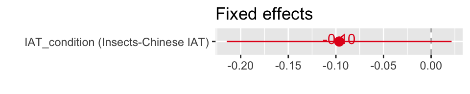

## Table predictions

| IAT condition | fit | se | lower | upper |
| --- | --- | --- | --- | --- |
| Flowers-Chinese IAT | 4.23 | 0.08 | 4.07 | 4.39 |
| Insects-Chinese IAT | 4.42 | 0.09 | 4.25 | 4.59 |

## Plot predictions

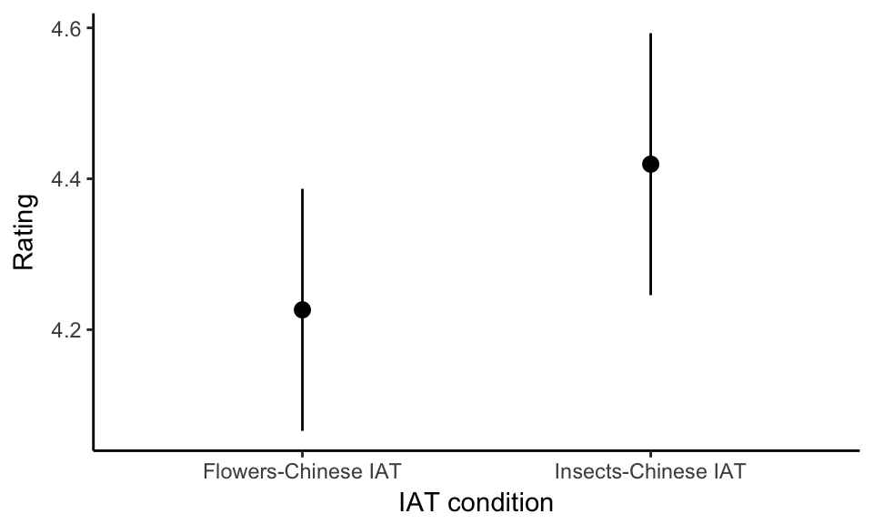